# Data Structures and Algorithms

Andres Castellano

June 11, 2020

### Mini Project 1

```python
from google.colab import drive
drive.mount('/content/gdrive/')
```

[output not shown]

```python
%cd /content/gdrive/My\ Drive/Mini-Project 1
```

**Step 1)** Construct a text file that follows the input specifications of the problem, i.e. it can serve as a sample input. Specifically, you should give an input file representing a 10x10 patch. The patch should contain two or three islands, according to your choice. The shape of the islands can be arbitrary, but try to be creative. The text file should be of the form firstname-lastname.txt. Notice that each cell in the patch is characterized by its coordinates. The top left coordinate is (0,0) and coordinate (i,j) is for the cell in the i-th row and j-th column.

[figure not shown]

**Step 2)** Write a function that reads an input file with the given specifications and returns the list of the coordinates of the land points, i.e. the list of coordinates for the ‘X’ points.

```python
f = open('andres-castellano.txt', 'r')
```

```python
def Coordinates(file):


    ''' This function will return a list,
    where each element of the list is a list itself of coordinates for each test case in the file.
    In the case where the input file only contains 1 test case, the function will return a list of length 1.'''

    import re
    f.seek(0)
    coor = []

    num_cases = int(f.readlines(1)[0][0])
    print("Number of test cases is: {} \n".format(num_cases))


    for case in range(num_cases):
        print('For test case {} ... '.format(case+1))

        dims = re.findall('\d+', f.readlines(1)[0])
        i = int(dims[0])
        j = int(dims[1])
        case_coor = []

        print('Dimensions are {0} by {1} \n'.format(i,j))

        for ith in range(i):
            line = f.readlines(1)[0]
            for jth in range(j):
                if line[jth] == "x":
                    #print(ith+1,jth+1)
                    case_coor.append((ith+1,jth+1))
        #print(case_coor)
        coor.append(case_coor)

    return coor
```

```python
Coordinates(f)
```

```
Number of test cases is: 2

For test case 1 ...
Dimensions are 10 by 10

For test case 2 ...
Dimensions are 20 by 20
```

```
[[(2, 3),
  (2, 8),
  (4, 5),
  (4, 6),
  (5, 2),
  (5, 9),
  (6, 3),
  (6, 8),
  (7, 4),
  (7, 7),
  (8, 5),
  (8, 6),
  (9, 9)],
 [(3, 10),
  (3, 11),
  (3, 12),
  (3, 13),
  (4, 10),
  (4, 11),
  (4, 12),
  (4, 13),
  (5, 12),
  (5, 13),
  (6, 12),
  (6, 13),
  (7, 3),
  (7, 4),
  (7, 12),
  (7, 13),
  (8, 3),
  (8, 4),
  (8, 12),
  (8, 13),
  (9, 3),
  (9, 4),
  (9, 5),
  (9, 6),
  (9, 16),
  (9, 17),
  (10, 3),
```

[output cut: 40 more lines]

```
  (18, 12),
  (18, 16),
  (18, 17),
  (18, 18),
  (18, 19),
  (19, 3),
  (19, 4),
  (19, 7),
  (19, 8),
  (19, 11),
  (19, 12),
  (19, 16),
  (19, 17),
  (19, 18),
  (19, 19)]]
```

**Step 3)** Write a function CoordinateToNumber(i, j, m, n) that takes a coordinate (i, j) and maps it to a unique number t in [0, mn − 1], which is then returned by the function.

I'm assuming this step is directing us to create a function that takes a list of coordinates and generates unique identifiers for each coordinate within the list.

```python
def CoordinateToNumber(coordinate_list=list,m=int,n=int):
    '''Returns a list for a list of coordinates as input,
    returns a tuple for a coordinate as input'''
    global T
    if len(coordinate_list) > m*n:
        raise Exception('Stop, too many coordinates for mXn')
    if type(coordinate_list) is tuple:
        T = {0 : coordinate_list}
    else:
        for value in enumerate(coordinate_list):
            T = dict(val for val in enumerate(coordinate_list))
    return T
```

```python
CoordinateToNumber(Coordinates(f)[0],10,10)
```

```
Number of test cases is: 2

For test case 1 ...
Dimensions are 10 by 10

For test case 2 ...
Dimensions are 20 by 20
```

```
{0: (2, 3),
 1: (2, 8),
 2: (4, 5),
 3: (4, 6),
 4: (5, 2),
 5: (5, 9),
 6: (6, 3),
 7: (6, 8),
 8: (7, 4),
 9: (7, 7),
 10: (8, 5),
 11: (8, 6),
 12: (9, 9)}
```

**Step 4)** Write a function NumberToCoordinate(t, m, n) that takes a number t and returns the corresponding coordinate. This function must be the inverse of CoordinateToNumber. That is, for all i, j, m, n we must have

NumberToCoordinate(CoordinateToNumber(i, j, m, n), m, n) = (i, j)

The two steps above mean that besides its coordinates, each cell has its own unique identity number in [0, mn − 1]

```python
def NumberToCoordinate(L=list,m=int,n=int):
    '''Returns a list size n of tuples for a list of inputs of size n'''
    coordinate_list = []
    for key in L:
        coordinate_list.append(T.get(key))
    return coordinate_list
```

```python
NumberToCoordinate(CoordinateToNumber(Coordinates(f)[0],10,10),10,10)
```

```
Number of test cases is: 2

For test case 1 ...
Dimensions are 10 by 10

For test case 2 ...
Dimensions are 20 by 20
```

```
[(2, 3),
 (2, 8),
 (4, 5),
 (4, 6),
 (5, 2),
 (5, 9),
 (6, 3),
 (6, 8),
 (7, 4),
 (7, 7),
 (8, 5),
 (8, 6),
 (9, 9)]
```

### Note 1:

The functions as defined above take as inputs iterable objects as seen above. However. All functions can also be called on specific coordinates.

For example:

The below code will call the identifier and coordinates of one single cell from test case 1.

```python
Coordinates(f)[0][5] # Gets the 6th coordinate of test case 1.
```

```
Number of test cases is: 2

For test case 1 ...
Dimensions are 10 by 10

For test case 2 ...
Dimensions are 20 by 20
```

```
(5, 9)
```

```python
CoordinateToNumber(Coordinates(f)[0][5],10,10) # Gets the identifier and coordinates for the 6th coordinate of case 1.
```

```
Number of test cases is: 2

For test case 1 ...
Dimensions are 10 by 10

For test case 2 ...
Dimensions are 20 by 20
```

```
{0: (5, 9)}
```

```python
NumberToCoordinate(CoordinateToNumber(Coordinates(f)[0][5],10,10),10,10)
```

```
Number of test cases is: 2

For test case 1 ...
Dimensions are 10 by 10

For test case 2 ...
Dimensions are 20 by 20
```

```
[(5, 9)]
```

The last line of code gets the coordinate from the correspondng identifier given to the coordinate 6 of test case 1. Note that Coordinates(f)[0][5] and NumberToCoordinate(CoordinateToNumber(Coordinates(f)[0][5])) should return the same coordinate and it does.

**Step 5)** Write a function Distance(t1, t2), where t1 and t2 are the identity numbers of two cells, and the output is the distance between them. The distance is the minimum number of connected cells that one has to traverse to go from t1 to t2. (Hint: Use function NumberToCoordinate for this)

```python
CoordinateToNumber(Coordinates(f)[0],10,10)
```

```
Number of test cases is: 2

For test case 1 ...
Dimensions are 10 by 10

For test case 2 ...
Dimensions are 20 by 20
```

```
{0: (2, 3),
 1: (2, 8),
 2: (4, 5),
 3: (4, 6),
 4: (5, 2),
 5: (5, 9),
 6: (6, 3),
 7: (6, 8),
 8: (7, 4),
 9: (7, 7),
 10: (8, 5),
 11: (8, 6),
 12: (9, 9)}
```

```python
def Distance(t1=int,t2=int):
    '''Returns a scalar representing the manhattan distance between two coordinates representing input identifiers t1 and t2. '''
    t1 = T[t1]
    t2 = T[t2]

    distance = abs(t2[1]-t1[1]) + abs(t2[0]-t1[0])

    return distance

Distance(0,1) == abs(8-3)+abs(2-2)
```

```
True
```

Recall that in **Step 2** we wrote a function for finding the list of land cells. Let’s call this function **FindLandCells**, and its output **LandCell_List**. This list of land cells can look like this:

LandCell List = [10, 11, 25, 12, 50, 51, 80, 81, 82] (this is only an example, it does not correspond to some specific input).

```python
FindLandCells = CoordinateToNumber
LandCell_List = CoordinateToNumber(Coordinates(f)[1],20,20)
LandCell_List.keys()
```

```
Number of test cases is: 2

For test case 1 ...
Dimensions are 10 by 10

For test case 2 ...
Dimensions are 20 by 20
```

```
dict_keys([0, 1, 2, 3, 4, 5, 6, 7, 8, 9, 10, 11, 12, 13, 14, 15, 16, 17, 18, 19, 20, 21, 22, 23, 24, 25, 26, 27, 28, 29, 30, 31, 32, 33, 34, 35, 36, 37, 38, 39, 40, 41, 42, 43, 44, 45, 46, 47, 48, 49, 50, 51, 52, 53, 54, 55, 56, 57, 58, 59, 60, 61, 62, 63, 64, 65, 66, 67, 68, 69, 70, 71, 72, 73, 74,…
```

Now this lists can be further broken into islands. So, we have something that looks like this:

Island_List = [[10, 11, 12], [25], [50, 51], [80, 81, 82]]

You see how all the cells from the original list appear in the second data structure, which is a list of lists, with each list being an island. Observe how cells belonging to the same island (e.g. cell 12), can be mixed up with other islands in LandCell List. In other words, one island’s cells do not have to be in contiguous positions in LandCell List.

In this section we will write functions to help find the list of islands.

**Step 6)** Write a function GenerateNeighbors(t1, n, m), that takes one cell number t1 (and also the dimensions), and returns the numbers for the neighbors of t1 in the grid. Notice that t1 can have 2, 3 or 4 neighbors.

```python
CoordinateToNumber(Coordinates(f)[0],10,10)
```

```
Number of test cases is: 2

For test case 1 ...
Dimensions are 10 by 10

For test case 2 ...
Dimensions are 20 by 20
```

```
{0: (2, 3),
 1: (2, 8),
 2: (4, 5),
 3: (4, 6),
 4: (5, 2),
 5: (5, 9),
 6: (6, 3),
 7: (6, 8),
 8: (7, 4),
 9: (7, 7),
 10: (8, 5),
 11: (8, 6),
 12: (9, 9)}
```

```python
def GenerateNeighbors(t1=int,m=int,n=int):

    coordinates = T[t1]
    row_neighboors = []
    candidates = []

    row_candidates = [(coordinates[0],coordinates[1]-1),(coordinates[0],coordinates[1]+1)]
    [candidates.append(x) for x in row_candidates]


    col_candidates = [(coordinates[0]-1,coordinates[1]),(coordinates[0]+1,coordinates[1])]
    [candidates.append(x) for x in col_candidates]

    #return [x in T.values() for x in candidates]
    return sum([x in T.values() for x in candidates])
```

```python
GenerateNeighbors(2,10,10)
```

```
1
```

**Step 7)** Write a function ExploreIsland(t1, n, m). This function should start from cell t1, and construct a list of cells that are in the same island as t1. (Hint: t1 can add itself to a dictionary representing the island, and also its neighbors, then the neighbors should recursively do the the same. But when new neighbors are inserted in the dictionary, we should first check if they are already in it. The process should terminate when it’s not possible to add more cells to the dictionary, meaning that we found the island. Finally the function should return a list with the cells on the island)

```python
FindLandCells = CoordinateToNumber
LandCell_List = CoordinateToNumber(Coordinates(f)[0],10,10)
LandCell_List.keys()
```

```
Number of test cases is: 2

For test case 1 ...
Dimensions are 10 by 10

For test case 2 ...
Dimensions are 20 by 20
```

```
dict_keys([0, 1, 2, 3, 4, 5, 6, 7, 8, 9, 10, 11, 12])
```

```python
def ExploreIsland(t1=int,m=int,n=int, neighbors=[]):

    coordinates = T[t1]
    candidates = []
    if neighbors == []:
        neighbors.append(t1)

    row_candidates = [(coordinates[0],coordinates[1]-1),(coordinates[0],coordinates[1]+1)]
    [candidates.append(x) for x in row_candidates]


    col_candidates = [(coordinates[0]-1,coordinates[1]),(coordinates[0]+1,coordinates[1])]
    [candidates.append(x) for x in col_candidates]

    print("\nFor Land {0} with coordinates {1}, Candidates are {2} ".format(t1, coordinates, candidates))

    for x in candidates:
        print("  ...Checking coordinates {} for land {}".format(x,t1))
        if x in T.values():
            for key, value in T.items():
                if value == x and key in neighbors:
                    print("            Land {} already on Island with land {}!            ".format(key,t1))
                if value == x and key not in neighbors:
                    print("      ...Adding land {} with coordinates {} to land {} ".format(key,x,t1))
                    neighbors.append(key)
                    print("\nExploring land {}____________\n".format(key))
                    ExploreIsland(key,m,n,neighbors)

    #print("Island consists of Lands {}".format(neighbors))
    return neighbors
    #neighbors.append()
```

```python
ExploreIsland(10,10,10,neighbors=[])
```

```
For Land 10 with coordinates (8, 5), Candidates are [(8, 4), (8, 6), (7, 5), (9, 5)]
  ...Checking coordinates (8, 4) for land 10
  ...Checking coordinates (8, 6) for land 10
      ...Adding land 11 with coordinates (8, 6) to land 10

Exploring land 11____________


For Land 11 with coordinates (8, 6), Candidates are [(8, 5), (8, 7), (7, 6), (9, 6)]
  ...Checking coordinates (8, 5) for land 11
            Land 10 already on Island with land 11!
  ...Checking coordinates (8, 7) for land 11
  ...Checking coordinates (7, 6) for land 11
  ...Checking coordinates (9, 6) for land 11
  ...Checking coordinates (7, 5) for land 10
  ...Checking coordinates (9, 5) for land 10
```

```
[10, 11]
```

```python
FindLandCells = CoordinateToNumber
LandCell_List = FindLandCells(Coordinates(f)[1],20,20)
LandCell_List.keys()
```

```
Number of test cases is: 2

For test case 1 ...
Dimensions are 10 by 10

For test case 2 ...
Dimensions are 20 by 20
```

```
dict_keys([0, 1, 2, 3, 4, 5, 6, 7, 8, 9, 10, 11, 12, 13, 14, 15, 16, 17, 18, 19, 20, 21, 22, 23, 24, 25, 26, 27, 28, 29, 30, 31, 32, 33, 34, 35, 36, 37, 38, 39, 40, 41, 42, 43, 44, 45, 46, 47, 48, 49, 50, 51, 52, 53, 54, 55, 56, 57, 58, 59, 60, 61, 62, 63, 64, 65, 66, 67, 68, 69, 70, 71, 72, 73, 74,…
```

```python
ExploreIsland(0,20,20,neighbors=[])
```

```
For Land 0 with coordinates (3, 10), Candidates are [(3, 9), (3, 11), (2, 10), (4, 10)]
  ...Checking coordinates (3, 9) for land 0
  ...Checking coordinates (3, 11) for land 0
      ...Adding land 1 with coordinates (3, 11) to land 0

Exploring land 1____________


For Land 1 with coordinates (3, 11), Candidates are [(3, 10), (3, 12), (2, 11), (4, 11)]
  ...Checking coordinates (3, 10) for land 1
            Land 0 already on Island with land 1!
  ...Checking coordinates (3, 12) for land 1
      ...Adding land 2 with coordinates (3, 12) to land 1

Exploring land 2____________


For Land 2 with coordinates (3, 12), Candidates are [(3, 11), (3, 13), (2, 12), (4, 12)]
  ...Checking coordinates (3, 11) for land 2
            Land 1 already on Island with land 2!
  ...Checking coordinates (3, 13) for land 2
      ...Adding land 3 with coordinates (3, 13) to land 2

Exploring land 3____________


For Land 3 with coordinates (3, 13), Candidates are [(3, 12), (3, 14), (2, 13), (4, 13)]
  ...Checking coordinates (3, 12) for land 3
            Land 2 already on Island with land 3!
  ...Checking coordinates (3, 14) for land 3
  ...Checking coordinates (2, 13) for land 3
  ...Checking coordinates (4, 13) for land 3
      ...Adding land 7 with coordinates (4, 13) to land 3

Exploring land 7____________


For Land 7 with coordinates (4, 13), Candidates are [(4, 12), (4, 14), (3, 13), (5, 13)]
  ...Checking coordinates (4, 12) for land 7
      ...Adding land 6 with coordinates (4, 12) to land 7
```

[output cut: 129 more lines]

```
            Land 10 already on Island with land 8!
  ...Checking coordinates (4, 14) for land 7
  ...Checking coordinates (3, 13) for land 7
            Land 3 already on Island with land 7!
  ...Checking coordinates (5, 13) for land 7
            Land 9 already on Island with land 7!
  ...Checking coordinates (2, 12) for land 2
  ...Checking coordinates (4, 12) for land 2
            Land 6 already on Island with land 2!
  ...Checking coordinates (2, 11) for land 1
  ...Checking coordinates (4, 11) for land 1
            Land 5 already on Island with land 1!
  ...Checking coordinates (2, 10) for land 0
  ...Checking coordinates (4, 10) for land 0
            Land 4 already on Island with land 0!
```

```
[0, 1, 2, 3, 7, 6, 5, 4, 8, 9, 11, 10, 14, 15, 19, 18]
```

**Step 8)** Write a function FindIslands that reads the list LandCell_List and converts its to Island List as explained above. The idea for this step is to scan the list of land cells, and call repeatedly the ExploreIsland function.

```python
def FindIslands(LandCell_List=list):

    Island_List = []
    island = []
    checked = []

    for i in LandCell_List.keys():

        if i not in checked:

            print("Finding Islands Connected to Land {}".format(i))

            island = ExploreIsland(i,20,20,neighbors=[])
            [checked.append(x) for x in island]
            print("Explored island {}, consists of {}:".format(i, island))

            if len(island) < 1:
                Island_List.append([i])

            if island is not None:
                Island_List.append(island)
        else:
            next

    return Island_List
```

```python
Island_List = FindIslands(LandCell_List)
```

```
Finding Islands Connected to Land 0

For Land 0 with coordinates (3, 10), Candidates are [(3, 9), (3, 11), (2, 10), (4, 10)]
  ...Checking coordinates (3, 9) for land 0
  ...Checking coordinates (3, 11) for land 0
      ...Adding land 1 with coordinates (3, 11) to land 0

Exploring land 1____________


For Land 1 with coordinates (3, 11), Candidates are [(3, 10), (3, 12), (2, 11), (4, 11)]
  ...Checking coordinates (3, 10) for land 1
            Land 0 already on Island with land 1!
  ...Checking coordinates (3, 12) for land 1
      ...Adding land 2 with coordinates (3, 12) to land 1

Exploring land 2____________


For Land 2 with coordinates (3, 12), Candidates are [(3, 11), (3, 13), (2, 12), (4, 12)]
  ...Checking coordinates (3, 11) for land 2
            Land 1 already on Island with land 2!
  ...Checking coordinates (3, 13) for land 2
      ...Adding land 3 with coordinates (3, 13) to land 2

Exploring land 3____________


For Land 3 with coordinates (3, 13), Candidates are [(3, 12), (3, 14), (2, 13), (4, 13)]
  ...Checking coordinates (3, 12) for land 3
            Land 2 already on Island with land 3!
  ...Checking coordinates (3, 14) for land 3
  ...Checking coordinates (2, 13) for land 3
  ...Checking coordinates (4, 13) for land 3
      ...Adding land 7 with coordinates (4, 13) to land 3

Exploring land 7____________


For Land 7 with coordinates (4, 13), Candidates are [(4, 12), (4, 14), (3, 13), (5, 13)]
```

[output cut: 896 more lines]

```
  ...Checking coordinates (18, 20) for land 71
  ...Checking coordinates (17, 19) for land 71
            Land 61 already on Island with land 71!
  ...Checking coordinates (19, 19) for land 71
            Land 81 already on Island with land 71!
  ...Checking coordinates (16, 18) for land 60
  ...Checking coordinates (18, 18) for land 60
            Land 70 already on Island with land 60!
  ...Checking coordinates (16, 17) for land 59
  ...Checking coordinates (18, 17) for land 59
            Land 69 already on Island with land 59!
  ...Checking coordinates (16, 16) for land 58
  ...Checking coordinates (18, 16) for land 58
            Land 68 already on Island with land 58!
Explored island 58, consists of [58, 59, 60, 61, 71, 70, 69, 68, 78, 79, 80, 81]:
```

```python
Island_List
```

```
[[0, 1, 2, 3, 7, 6, 5, 4, 8, 9, 11, 10, 14, 15, 19, 18],
 [12, 13, 17, 16, 20, 21, 22, 23, 29, 28, 27, 26, 32, 33, 39, 38],
 [24, 25, 31, 30, 36, 35, 34, 40, 41, 42, 43, 37, 45, 44, 46, 47],
 [48, 49, 51, 50, 54, 55, 65, 64, 74, 75],
 [52, 53, 63, 62, 72, 73],
 [56, 57, 67, 66, 76, 77],
 [58, 59, 60, 61, 71, 70, 69, 68, 78, 79, 80, 81]]
```

**Step 9)** Write a function Island Distance(isl1, isl2), which takes two lists of cells representing two islands, and finds the distance of these two islands. For this you will need to compute the Distance function from Milestone 1.

```python
def Island_Distance(isl1=list,isl2=list):

    x0 = 'nothing'

    for i in isl1:

        if GenerateNeighbors(i,m=int,n=int) > 3: #Landlocked Land
            next
        else:

            #print("    Checking land {}".format(i))
            for j in isl2:

                if GenerateNeighbors(j,m=int,n=int) >3:
                    next
                else:

                    #print("Measuring land {} to land {}".format(i,j))

                    x1 = Distance(i,j)

                    if x0 == 'nothing':
                        x0 = x1

                    if x1 < x0:
                        x0 = x1
                        #print("\nNew Shortest Lenght is {}".format(x0))
    #print("\nShortest distance is {}\n".format(x0))
    return x0
```

```python
Island_Distance(Island_List[0],Island_List[1])
```

```
7
```

**Step 10)** We will now construct a graph of islands. Consider an example for this. Suppose Island List contains 3 islands. We will assign to each island a unique number in [0, 3). Then Island Graph will be a list of the following form:

[[0, 1, d(0, 1)], [0, 2, d(0, 2)], [1, 2, d(1, 2)]].

Here d(i, j) is the distance between islands i and j, as computed with the function in Step 9. In other words, for each pair of islands, we have a triple consisting of the identities of the pair, and their distance. This is a complete weighted graph. The goal of this Step is to write a function Island Graph that outputs this list.

```python
def Island_Graph(Island_List=list):

    import sys, os

    # For n islands in Island list, enumerate island on [0,3)

    output = []
    skip = []
    global dums
    dums = dict(val for val in enumerate(Island_List))

    for i in dums.keys():
        #print(i)
        skip.append(i)

        for j in dums.keys():

                if i == j or j in skip:
                    next
                    #print("skipped")

                else:

                    #sys.stdout = open(os.devnull, 'w')

                    y0 = [i,j,Island_Distance(dums[i],dums[j])]

                    output.append(y0)

                    #sys.stdout = sys.__stdout__

                    #print(y0)


    #print(output)
    print("\nLenght of output list is {}, ".format(len(output)),
          "which makes sense for a list of size {}, ".format(len(Island_List)),
          "Since {} times {} divided by 2 is {}.".format(len(Island_List),
                                                         len(Island_List)-1,
                                                         int(len(Island_List)*(len(Island_List)-1))/2))


    return output
```

```python
fun = Island_Graph(Island_List)
fun
```

```
Lenght of output list is 21,  which makes sense for a list of size 7,  Since 7 times 6 divided by 2 is 21.0.
```

```
[[0, 1, 7],
 [0, 2, 4],
 [0, 3, 11],
 [0, 4, 17],
 [0, 5, 9],
 [0, 6, 12],
 [1, 2, 9],
 [1, 3, 6],
 [1, 4, 5],
 [1, 5, 12],
 [1, 6, 17],
 [2, 3, 7],
 [2, 4, 13],
 [2, 5, 5],
 [2, 6, 4],
 [3, 4, 3],
 [3, 5, 3],
 [3, 6, 8],
 [4, 5, 7],
 [4, 6, 12],
 [5, 6, 4]]
```

**Final Step**

We now have a data structure which is the adjacency list (with weights) of the graphs. To connect all islands, we need to find a **minimum weight spanning tree** for this graph. I have seen one algorithm for computing such a tree in class. However, for this project, I will use the python library **networkx**.

```python
import networkx as nx
```

```python
G = nx.Graph()
```

```python
G.clear()

for i in range(len(fun)):
    print(fun[i][0],fun[i][1],fun[i][2])
    G.add_edge(fun[i][0],fun[i][1], weight=fun[i][2])
```

```
0 1 7
0 2 4
0 3 11
0 4 17
0 5 9
0 6 12
1 2 9
1 3 6
1 4 5
1 5 12
1 6 17
2 3 7
2 4 13
2 5 5
2 6 4
3 4 3
3 5 3
3 6 8
4 5 7
4 6 12
5 6 4
```

```python
mst = nx.tree.minimum_spanning_edges(G, algorithm='kruskal', data=False)
```

```python
edgelist = list(mst)
```

```python
sorted(sorted(e) for e in edgelist)
```

```
[[0, 2], [1, 4], [2, 6], [3, 4], [3, 5], [5, 6]]
```

```python
arbol = sorted(sorted(e) for e in edgelist)
```

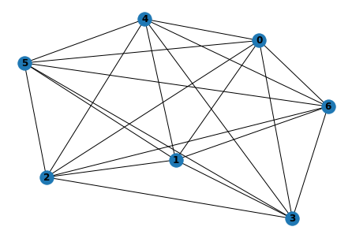

```python
 nx.draw(G, with_labels=True, font_weight='bold')
```

```python
EDGY = []
for item in edgelist:

    #print(item[0],item[1])

    i = item[0]
    j = item[1]

    #print(i)

    k = Island_Distance(Island_List[i],Island_List[j])

    EDGY.append(k)

    length = sum(EDGY)

print(length)
```

```
23
```

```python
print("The minimum cost to build the bridges required to connect all the islands is {}.".format(length))
```

```
The minimum cost to build the bridges required to connect all the islands is 23.
```

### Note:

The last part of the project was executed using the image and coordinates of the second patch on the text file.